# Course Project

Practical Machine Learning (*from Data Science Specialization*)

Renata Guanaes Machado

30/03/2021

## **Executive Summary**

Using devices such as Jawbone Up, Nike FuelBand, and Fitbit it is now possible to collect a large amount of data about personal activity relatively inexpensively. Using data from accelerometers on the belt, forearm, arm, and dumbell of 6 participants, the goal of this project is to predict the manner in which they did the exercise - in other words, **to predict the “class” according to existing and chosen predictors**.

A report should be made, describing:

- how the model was built;
- how cross validation was used;
- what the expected out of sample error is;
- why the choices were made.

More information can be accessed in this link: http://groupware.les.inf.puc-rio.br/har

### **Libraries and Setup**

```r
library(caret)
library(randomForest)
library(e1071)
library(ggplot2)
library(dplyr)
library(tidyr)
library(rattle)
library(doParallel)
set.seed(42)
```

### **Loading train and test datasets**

The raw data comes from files that are loaded into train and test dataframes.

```r
pmlTrain <- read.csv('C:/Users/Renata/Documents/data/pml-training.csv', header=TRUE,
                     stringsAsFactors = F, na.strings = c("","NA","#DIV/0!"))
pmlTest  <- read.csv('C:/Users/Renata/Documents/data/pml-testing.csv', header=TRUE,
                     stringsAsFactors = F, na.strings = c("","NA", "#DIV/0!"))
dim(pmlTrain); dim(pmlTest)
```

```
## [1] 19622   160
```

```
## [1]  20 160
```

### **Checking missing values or non-predictor variables**

Exclude columns that are only NAN values. Also, remove columns that are not predictors (examples: index, column user_name). These values were detected when running the command str() on pmlTrain and pmlTest - not showed here due to the high number of columns.

```r
pmlTrain <- pmlTrain[, colSums(is.na(pmlTrain)) == 0]
pmlTest <-  pmlTest[, colSums(is.na(pmlTest)) == 0]
pmlTrain <- pmlTrain[, -c(1:7)]
pmlTest <-  pmlTest[, -c(1:7)]
dim(pmlTrain); dim(pmlTest)
```

```
## [1] 19622    53
```

```
## [1] 20 53
```

After cleaning, the number of predictors has decreased a lot. we have now the following data columns (predictors).

```r
colnames(pmlTrain)
```

```
##  [1] "roll_belt"            "pitch_belt"           "yaw_belt"
##  [4] "total_accel_belt"     "gyros_belt_x"         "gyros_belt_y"
##  [7] "gyros_belt_z"         "accel_belt_x"         "accel_belt_y"
## [10] "accel_belt_z"         "magnet_belt_x"        "magnet_belt_y"
## [13] "magnet_belt_z"        "roll_arm"             "pitch_arm"
## [16] "yaw_arm"              "total_accel_arm"      "gyros_arm_x"
## [19] "gyros_arm_y"          "gyros_arm_z"          "accel_arm_x"
## [22] "accel_arm_y"          "accel_arm_z"          "magnet_arm_x"
## [25] "magnet_arm_y"         "magnet_arm_z"         "roll_dumbbell"
## [28] "pitch_dumbbell"       "yaw_dumbbell"         "total_accel_dumbbell"
## [31] "gyros_dumbbell_x"     "gyros_dumbbell_y"     "gyros_dumbbell_z"
## [34] "accel_dumbbell_x"     "accel_dumbbell_y"     "accel_dumbbell_z"
## [37] "magnet_dumbbell_x"    "magnet_dumbbell_y"    "magnet_dumbbell_z"
## [40] "roll_forearm"         "pitch_forearm"        "yaw_forearm"
## [43] "total_accel_forearm"  "gyros_forearm_x"      "gyros_forearm_y"
## [46] "gyros_forearm_z"      "accel_forearm_x"      "accel_forearm_y"
## [49] "accel_forearm_z"      "magnet_forearm_x"     "magnet_forearm_y"
## [52] "magnet_forearm_z"     "classe"
```

### **Splitting Training Data**

We need to split Training Data (pmlTrain) into training and testing datasets.

- training: it is used to estimate the model parameters
- testing: only after model building, it is used to assess model accuracy.

```r
set.seed(42)
inTrain  <- createDataPartition(y=pmlTrain$classe,  p=0.8, list=FALSE)
training <- pmlTrain[inTrain,]
testing  <- pmlTrain[-inTrain,]
dim(training); dim(testing)
```

```
## [1] 15699    53
```

```
## [1] 3923   53
```

### **Summary of Training dataset**

It is important to check that all predictors are numeric (except for the class variable), in order to check if we need to convert categorical predictors to numeric type.

```r
str(training)
```

```
## 'data.frame':    15699 obs. of  53 variables:
##  $ roll_belt           : num  1.41 1.41 1.42 1.48 1.48 1.42 1.42 1.43 1.45 1.45 ...
##  $ pitch_belt          : num  8.07 8.07 8.07 8.05 8.07 8.09 8.13 8.16 8.17 8.18 ...
##  $ yaw_belt            : num  -94.4 -94.4 -94.4 -94.4 -94.4 -94.4 -94.4 -94.4 -94.4 -94.4 ...
##  $ total_accel_belt    : int  3 3 3 3 3 3 3 3 3 3 ...
##  $ gyros_belt_x        : num  0 0.02 0 0.02 0.02 0.02 0.02 0.02 0.03 0.03 ...
##  $ gyros_belt_y        : num  0 0 0 0 0.02 0 0 0 0 0 ...
##  $ gyros_belt_z        : num  -0.02 -0.02 -0.02 -0.03 -0.02 -0.02 -0.02 -0.02 0 -0.02 ...
##  $ accel_belt_x        : int  -21 -22 -20 -22 -21 -22 -22 -20 -21 -21 ...
##  $ accel_belt_y        : int  4 4 5 3 2 3 4 2 4 2 ...
##  $ accel_belt_z        : int  22 22 23 21 24 21 21 24 22 23 ...
##  $ magnet_belt_x       : int  -3 -7 -2 -6 -6 -4 -2 1 -3 -5 ...
##  $ magnet_belt_y       : int  599 608 600 604 600 599 603 602 609 596 ...
##  $ magnet_belt_z       : int  -313 -311 -305 -310 -302 -311 -313 -312 -308 -317 ...
##  $ roll_arm            : num  -128 -128 -128 -128 -128 -128 -128 -128 -128 -128 ...
```

[output cut: 39 more lines]

### **Exploratory Data Analysis**

Checking classe distribution in order to verify if it is an imbalanced outcome.

```r
training$classe <- factor(training$classe)
testing$classe <- factor(testing$classe)
tab_classes <- as.data.frame(table(training$classe))
tab_classes
```

```
##   Var1 Freq
## 1    A 4464
## 2    B 3038
## 3    C 2738
## 4    D 2573
## 5    E 2886
```

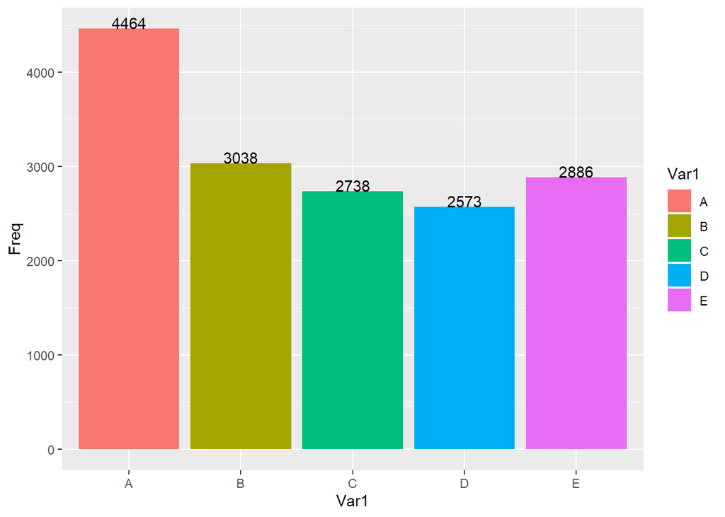

```r
ggplot(tab_classes, aes(x = Var1, y = Freq, fill = Var1)) +  # Plot with values on top
  geom_bar(stat = "identity") +
  geom_text(aes(label = Freq), vjust = 0)
```

### **Checking Correlation between variables**

Sometimes there will be variables that are highly correlated with each other. In this case, it’s not useful to include every variable in the model.

```r
Corr <- abs(cor(training [, -53] ) )
diag(Corr) <- 0
which(Corr > 0.8, arr.ind=T)
```

```
##                  row col
## yaw_belt           3   1
## total_accel_belt   4   1
## accel_belt_y       9   1
## accel_belt_z      10   1
## accel_belt_x       8   2
## magnet_belt_x     11   2
## roll_belt          1   3
## roll_belt          1   4
## accel_belt_y       9   4
## accel_belt_z      10   4
## pitch_belt         2   8
## magnet_belt_x     11   8
## roll_belt          1   9
## total_accel_belt   4   9
## accel_belt_z      10   9
## roll_belt          1  10
## total_accel_belt   4  10
## accel_belt_y       9  10
## pitch_belt         2  11
## accel_belt_x       8  11
## gyros_arm_y       19  18
## gyros_arm_x       18  19
## magnet_arm_x      24  21
## accel_arm_x       21  24
## magnet_arm_z      26  25
## magnet_arm_y      25  26
## accel_dumbbell_x  34  28
## accel_dumbbell_z  36  29
## gyros_dumbbell_z  33  31
## gyros_forearm_z   46  31
## gyros_dumbbell_x  31  33
## gyros_forearm_z   46  33
## pitch_dumbbell    28  34
## yaw_dumbbell      29  36
## gyros_forearm_z   46  45
## gyros_dumbbell_x  31  46
## gyros_dumbbell_z  33  46
## gyros_forearm_y   45  46
```

### **Reducing Dimensionality: PCA**

Dimensionality reduction involves decreasing the number of input variables (predictors) in modeling data. Therefore, PCA (Principal Components Analysis) will be performed as a pre-processing step to model buiding, in order to reduce the high dimensionality. We will use the R function prcomp(). Using scale = TRUE means that variables should be scaled to have unit variance (standard deviation = 1).

```r
prin_comp <- prcomp(x = training[,-53], scale. = TRUE) # remove the Class variable
```

```r
#biplot(prin_comp, scale=0)
```

```r
pr_var <- (prin_comp$sdev)^2
prop_varex <- pr_var/sum(pr_var)
#prop_varex[1:36]
sum(prop_varex[1:36])
```

```
## [1] 0.9907657
```

Plotting a cumulative variance plot shows the number of components that explains variability.

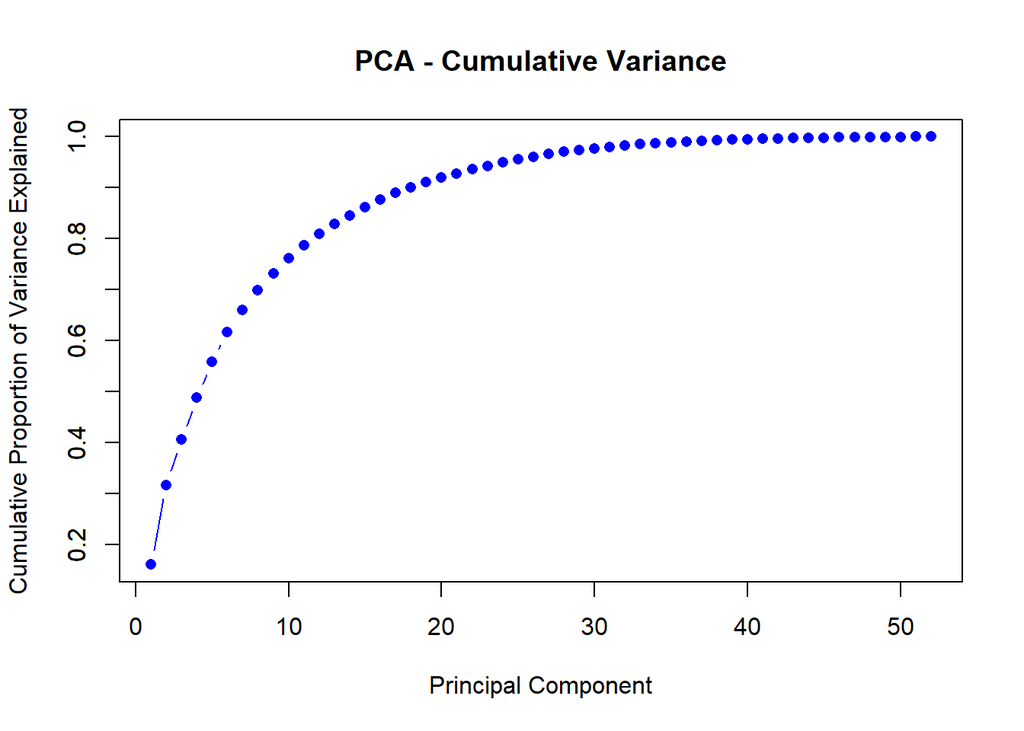

```r
plot(cumsum(prop_varex),
                  xlab="Principal Component",
                  ylab="Cumulative Proportion of Variance Explained",
                  type="b",
                  main = "PCA - Cumulative Variance",
                  pch=16, col="blue")
axis(2, seq(0,1,0.1))
```

PCA using caret package (same results: 36 variables explain 99% variability).

```r
preproc <- preProcess(training[,-53], method='pca', thresh=0.99)
trainingPCA <- predict(preproc, training[,-53])
testingPCA <- predict(preproc, testing[,-53])
testing_to_predict.pca <- predict(preproc, testing[,-53])
dim(trainingPCA)
```

```
## [1] 15699    36
```

```r
# include Class
trainingPCA <- data.frame(classe = training$classe, prin_comp$x)
trainingPCA <- trainingPCA[,1:37]
```

### **Model building with training dataset**

Using training dataset (not dataset transformed by PCA method), the following methods will be used to fit the model:

- Decision Tree (tree),
- RandomForest (rf) and
- Stochastic Gradient Boosting (gbm).

We can check which one provides the best out-of-sample accuracy.

#### **Decision tree**

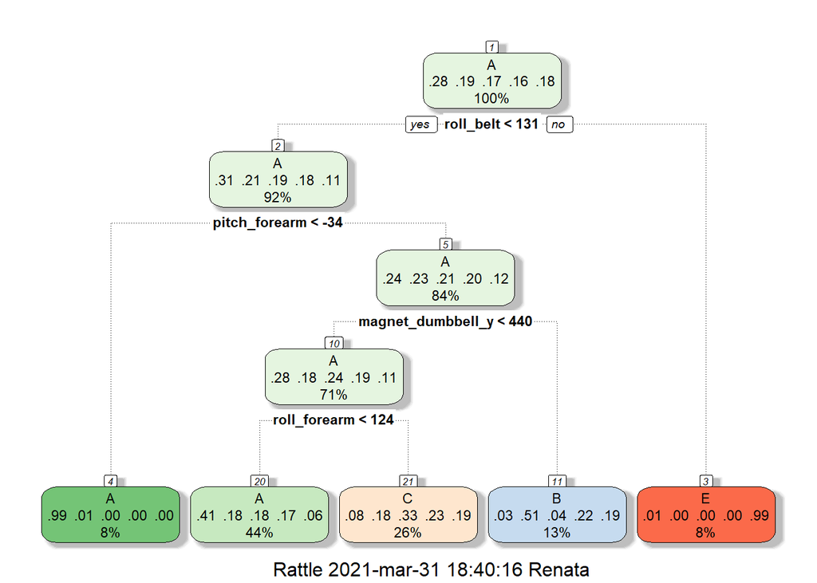

```r
set.seed(42)
treeFit <- train(classe ~ ., method="rpart", data = training)
#print(treeFit$finalModel) # hard to visualize
fancyRpartPlot(treeFit$finalModel)
```

```r
treePred <- predict(treeFit, newdata=testing)
confusionMatrix(treePred, testing$classe)
```

```
## Confusion Matrix and Statistics
##
##           Reference
## Prediction    A    B    C    D    E
##          A 1009  321  311  283  105
##          B   13  241   23  106   90
##          C   94  197  350  254  200
##          D    0    0    0    0    0
##          E    0    0    0    0  326
##
## Overall Statistics
##
##                Accuracy : 0.491
##                  95% CI : (0.4752, 0.5067)
##     No Information Rate : 0.2845
##     P-Value [Acc > NIR] : < 2.2e-16
##
##                   Kappa : 0.3351
##
##  Mcnemar's Test P-Value : NA
##
## Statistics by Class:
##
##                      Class: A Class: B Class: C Class: D Class: E
## Sensitivity            0.9041  0.31752  0.51170   0.0000   0.4521
## Specificity            0.6366  0.92668  0.76999   1.0000   1.0000
## Pos Pred Value         0.4973  0.50951  0.31963      NaN   1.0000
## Neg Pred Value         0.9435  0.84986  0.88190   0.8361   0.8902
## Prevalence             0.2845  0.19347  0.17436   0.1639   0.1838
## Detection Rate         0.2572  0.06143  0.08922   0.0000   0.0831
## Detection Prevalence   0.5172  0.12057  0.27912   0.0000   0.0831
## Balanced Accuracy      0.7704  0.62210  0.64084   0.5000   0.7261
```

#### **Random Forest**

```r
set.seed(42)
ncores <- makeCluster(detectCores() - 1)
registerDoParallel(cores=ncores)
getDoParWorkers() # 3
```

```
## [1] 3
```

```r
rfFit <- train(classe ~ . , method = "rf", prox=TRUE, ntree = 100,
               data = training,
               importance=TRUE,
               metric = "Accuracy",             # categorical outcome variable
               preProcess=c("center", "scale"), # normalize data
               trControl=trainControl(method = "cv"
                                        , number = 5  # folds for training data
                                        , p= 0.60
                                        , allowParallel = TRUE
                                        )
                )
stopCluster(ncores)
```

```r
rfFit
```

```
## Random Forest
##
## 15699 samples
##    52 predictor
##     5 classes: 'A', 'B', 'C', 'D', 'E'
##
## Pre-processing: centered (52), scaled (52)
## Resampling: Cross-Validated (5 fold)
## Summary of sample sizes: 12560, 12558, 12560, 12559, 12559
## Resampling results across tuning parameters:
##
##   mtry  Accuracy   Kappa
##    2    0.9906361  0.9881537
##   27    0.9923560  0.9903304
##   52    0.9842026  0.9800140
##
## Accuracy was used to select the optimal model using the largest value.
## The final value used for the model was mtry = 27.
```

```r
rfFit$finalModel
```

```
##
## Call:
##  randomForest(x = x, y = y, ntree = 100, mtry = param$mtry, importance = TRUE,      proximity = TRUE)
##                Type of random forest: classification
##                      Number of trees: 100
## No. of variables tried at each split: 27
##
##         OOB estimate of  error rate: 0.64%
## Confusion matrix:
##      A    B    C    D    E  class.error
## A 4460    3    0    0    1 0.0008960573
## B   22 3008    7    1    0 0.0098749177
## C    0   14 2714   10    0 0.0087655223
## D    0    1   27 2544    1 0.0112708900
## E    0    1    4    8 2873 0.0045045045
```

```r
rfPred <- predict(rfFit, newdata=testing)
confusionMatrix(rfPred, testing$classe)
```

```
## Confusion Matrix and Statistics
##
##           Reference
## Prediction    A    B    C    D    E
##          A 1115    2    0    0    0
##          B    1  757    5    0    0
##          C    0    0  677   13    1
##          D    0    0    2  630    0
##          E    0    0    0    0  720
##
## Overall Statistics
##
##                Accuracy : 0.9939
##                  95% CI : (0.9909, 0.9961)
##     No Information Rate : 0.2845
##     P-Value [Acc > NIR] : < 2.2e-16
##
##                   Kappa : 0.9923
##
##  Mcnemar's Test P-Value : NA
##
## Statistics by Class:
##
##                      Class: A Class: B Class: C Class: D Class: E
## Sensitivity            0.9991   0.9974   0.9898   0.9798   0.9986
## Specificity            0.9993   0.9981   0.9957   0.9994   1.0000
## Pos Pred Value         0.9982   0.9921   0.9797   0.9968   1.0000
## Neg Pred Value         0.9996   0.9994   0.9978   0.9960   0.9997
## Prevalence             0.2845   0.1935   0.1744   0.1639   0.1838
## Detection Rate         0.2842   0.1930   0.1726   0.1606   0.1835
## Detection Prevalence   0.2847   0.1945   0.1761   0.1611   0.1835
## Balanced Accuracy      0.9992   0.9977   0.9927   0.9896   0.9993
```

Random Forest: the most important variables in the model.

```r
varImp(rfFit)
```

```
## rf variable importance
##
##   variables are sorted by maximum importance across the classes
##   only 20 most important variables shown (out of 52)
##
##                           A     B     C     D      E
## roll_belt            69.758 87.47 74.29 78.99 100.00
## magnet_dumbbell_y    61.649 59.06 88.94 59.27  52.61
## pitch_belt           25.266 87.83 53.03 42.97  32.95
## pitch_forearm        48.425 68.03 80.03 46.50  50.68
## yaw_belt             64.678 57.57 65.46 78.90  44.84
## magnet_dumbbell_z    67.759 50.79 58.37 42.77  52.63
## accel_forearm_x      12.182 33.31 26.46 44.60  25.98
## roll_forearm         43.260 37.55 44.49 31.06  32.49
## gyros_belt_z         14.335 27.01 30.79 17.34  43.27
## gyros_dumbbell_y     31.737 28.91 39.29 18.69  18.59
## yaw_arm              37.500 23.76 22.67 29.76  19.36
## accel_dumbbell_y     30.748 25.83 35.81 22.84  27.18
## accel_dumbbell_z     16.695 26.67 20.59 27.44  29.90
## magnet_belt_y        11.671 29.39 24.36 15.67  20.96
## magnet_forearm_y     19.906 26.51 19.56 17.81  15.87
## roll_dumbbell        15.117 25.93 14.71 18.39  23.01
## total_accel_dumbbell  8.686 20.10 17.11 21.62  25.78
## yaw_forearm          13.930 21.22 14.50 25.08  12.50
## magnet_belt_z        16.711 23.99 20.06 24.95  21.22
## gyros_arm_y          24.952 21.97 16.26 22.63  15.83
```

#### **GBM**

```r
gbmFit <- train(classe ~ . , method = "gbm",
               data = training,
               verbose=FALSE,                   # less detailed summary
               metric = "Accuracy",             # categorical outcome variable
               preProcess=c("center", "scale"), # normalize data
               trControl=trainControl(method = "repeatedcv",
                                      number = 5,
                                      repeats=1))
```

```r
gbmFit
```

```
## Stochastic Gradient Boosting
##
## 15699 samples
##    52 predictor
##     5 classes: 'A', 'B', 'C', 'D', 'E'
##
## Pre-processing: centered (52), scaled (52)
## Resampling: Cross-Validated (5 fold, repeated 1 times)
## Summary of sample sizes: 12558, 12560, 12560, 12559, 12559
## Resampling results across tuning parameters:
##
##   interaction.depth  n.trees  Accuracy   Kappa
##   1                   50      0.7555905  0.6900714
##   1                  100      0.8205630  0.7728503
##   1                  150      0.8541957  0.8154592
##   2                   50      0.8561072  0.8176627
##   2                  100      0.9068106  0.8820784
##   2                  150      0.9325448  0.9146369
##   3                   50      0.8970011  0.8696719
##   3                  100      0.9442647  0.9294767
##   3                  150      0.9618454  0.9517291
##
## Tuning parameter 'shrinkage' was held constant at a value of 0.1
##
## Tuning parameter 'n.minobsinnode' was held constant at a value of 10
## Accuracy was used to select the optimal model using the largest value.
## The final values used for the model were n.trees = 150, interaction.depth =
##  3, shrinkage = 0.1 and n.minobsinnode = 10.
```

```r
gbmFit$finalModel
```

```
## A gradient boosted model with multinomial loss function.
## 150 iterations were performed.
## There were 52 predictors of which 52 had non-zero influence.
```

```r
gbmPred <- predict(gbmFit, newdata=testing)
confusionMatrix(gbmPred, testing$classe)
```

```
## Confusion Matrix and Statistics
##
##           Reference
## Prediction    A    B    C    D    E
##          A 1104   22    0    1    0
##          B    6  718   28    2    7
##          C    4   17  647   23    5
##          D    0    2    7  614    5
##          E    2    0    2    3  704
##
## Overall Statistics
##
##                Accuracy : 0.9653
##                  95% CI : (0.9591, 0.9708)
##     No Information Rate : 0.2845
##     P-Value [Acc > NIR] : < 2.2e-16
##
##                   Kappa : 0.9561
##
##  Mcnemar's Test P-Value : 7.93e-05
##
## Statistics by Class:
##
##                      Class: A Class: B Class: C Class: D Class: E
## Sensitivity            0.9892   0.9460   0.9459   0.9549   0.9764
## Specificity            0.9918   0.9864   0.9849   0.9957   0.9978
## Pos Pred Value         0.9796   0.9435   0.9296   0.9777   0.9902
## Neg Pred Value         0.9957   0.9870   0.9885   0.9912   0.9947
## Prevalence             0.2845   0.1935   0.1744   0.1639   0.1838
## Detection Rate         0.2814   0.1830   0.1649   0.1565   0.1795
## Detection Prevalence   0.2873   0.1940   0.1774   0.1601   0.1812
## Balanced Accuracy      0.9905   0.9662   0.9654   0.9753   0.9871
```

### **Conclusion**

It seems both Gradient boosting and Random Forests outperform the Decision Trees. Moreover, Random Forest has been slightly more accurate.

```r
treeCM <- confusionMatrix(treePred, testing$classe)
rfCM   <- confusionMatrix(rfPred, testing$classe)
gbmCM  <- confusionMatrix(gbmPred, testing$classe)
```

```r
AccuracyResults <- data.frame(
  Model = c('DecisionTree', 'RF', 'GBM'),
  Accuracy = rbind(treeCM$overall[1], rfCM$overall[1], gbmCM$overall[1])
)
print(AccuracyResults)
```

```
##          Model  Accuracy
## 1 DecisionTree 0.4909508
## 2           RF 0.9938822
## 3          GBM 0.9653327
```

As the model fitted with Random Forest model has the better accuracy, so it will be applied to predict the pmlTest dataset.

```r
print(predict(rfFit, newdata=pmlTest))
```

```
##  [1] B A B A A E D B A A B C B A E E A B B B
## Levels: A B C D E
```